# Targeting along a continuous gradient: the bathymetric example

Henning Winker FAO Fisheries and Aquaculture Division, Assessment and Management Team (NFIFM) henning.winker@fao.org

This example uses the spatial multispecies simulator of Thorson et al. (2017, Appendix A), which generalises the simulator of Ono et al. (2015), with the “Run 22” settings of the CPUE guidelines. Four species live along continuous depth-preference gradients over a simulated bathymetry, and 30 vessels move effort between them following species prices, which change in three 10-year blocks (species 1, then 2, then 4). The simulator is described in full in the [background document](https://henning-winker.github.io/cpueTargeting/appendix.html).

Positions are reported only as the centres of 5 x 5 blocks. This is the realistic case: logbooks rarely report positions at the scale at which fish and fleets interact, so a spatial term cannot resolve all spatial targeting.

# The simulated fishery

The code for the single run (seed 123); all results shown below were pre-run with `inst/scripts/run_bathymetric.R`:

```r
sim <- simulate_bathymetric(seed = 123, plots = FALSE)
```

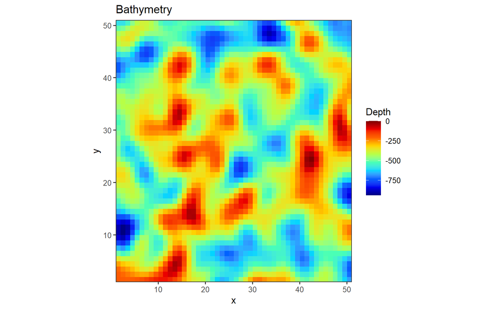

```r
p <- plot_om(sim)
p$Depth
```

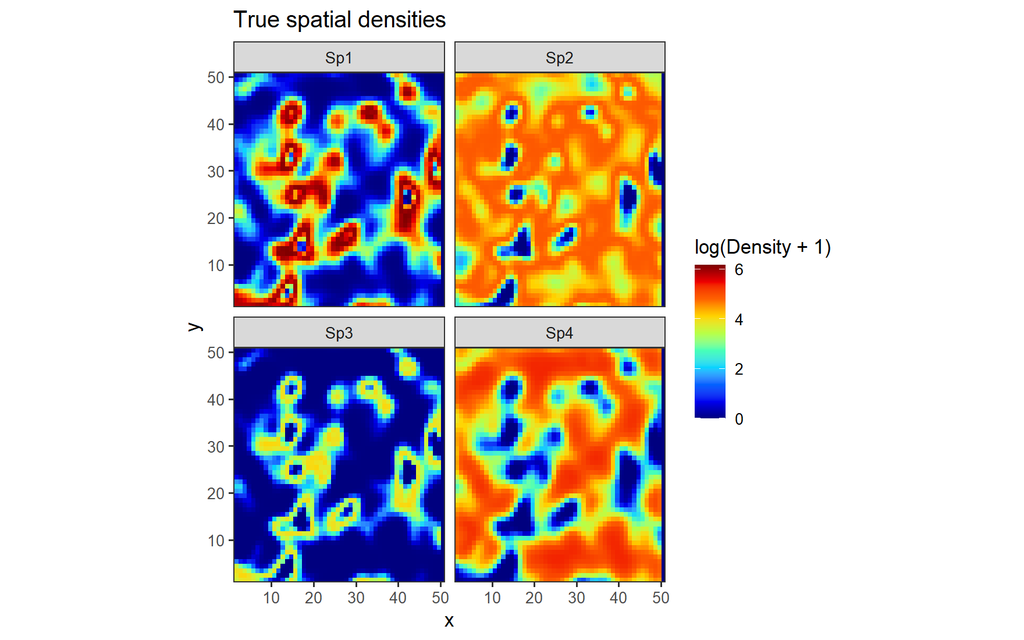

```r
p$SpDens
```

Species 1 and 3 live in patches; species 2 and 4 in the surrounding deeper water. Catches per set are zero-inflated and right-skewed, so Tweedie GAMs are used:

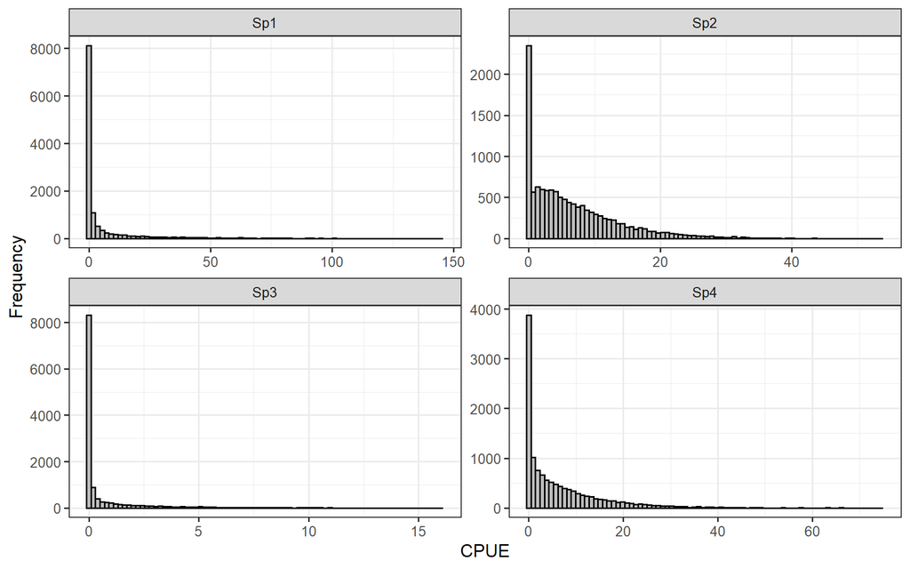

```r
p$Hist
```

Nominal CPUE (points) against the true biomass (blue): the price-driven targeting changes bias nominal CPUE by up to a factor of two.

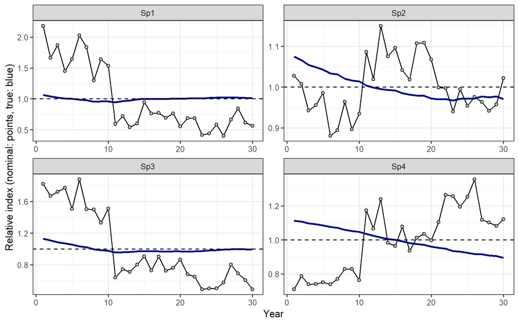

```r
p$CPUE
```

# Standardisation as in the guidelines

All models are Tweedie GAMs with `year` plus a targeting term. `+S` adds a spatial smoother `s(Xs, Ys, k = 8)` on the 5 x 5 blocks. As in the guidelines, the catch composition is reduced to two principal components (DPC) and three clusters (number of PCs + 1). The final DPC model is fitted as a GAMM with a random vessel effect.

```r
fit <- standardize_cpue(sim,
  models = c("Base", "Base+S", "Cluster+S", "DPC", "DPC+S"),
  n_pc = 2, n_clusters = 3, spatial_res = 5, spatial_k = 8, engine = "gam")
fit_re <- standardize_cpue(sim, models = "DPC+S",
  n_pc = 2, n_clusters = 3, spatial_res = 5, spatial_k = 8, engine = "gam",
  vessel_re = TRUE, label = " + vessel RE")
fit <- bind_comparisons(fit, fit_re)
```

```r
fit$formulas
```

```
##                                                                               Base
##                                                                             "year"
##                                                                             Base+S
##                                                          "year + s(Xs, Ys, k = 8)"
##                                                                          Cluster+S
##                                                     "year + s(Xs, Ys, k = 8) + FT"
##                                                                                DPC
##                                             "year + s(PC1, k = 3) + s(PC2, k = 3)"
##                                                                              DPC+S
##                          "year + s(Xs, Ys, k = 8) + s(PC1, k = 3) + s(PC2, k = 3)"
##                                                                  DPC+S + vessel RE
## "year + s(Xs, Ys, k = 8) + s(PC1, k = 3) + s(PC2, k = 3) + s(vessel, bs = \"re\")"
```

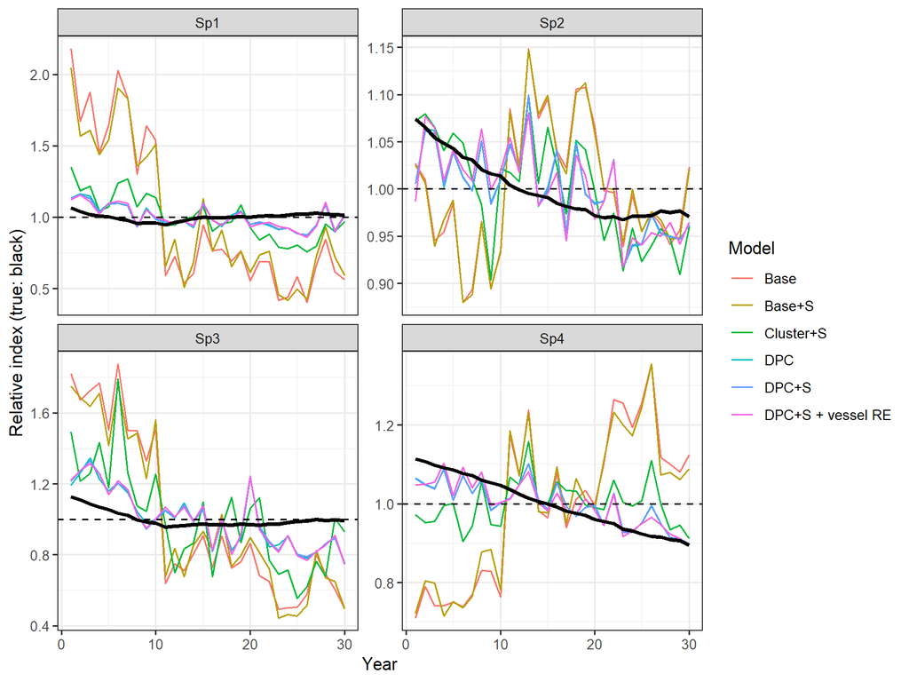

```r
plot_indices(fit)
```

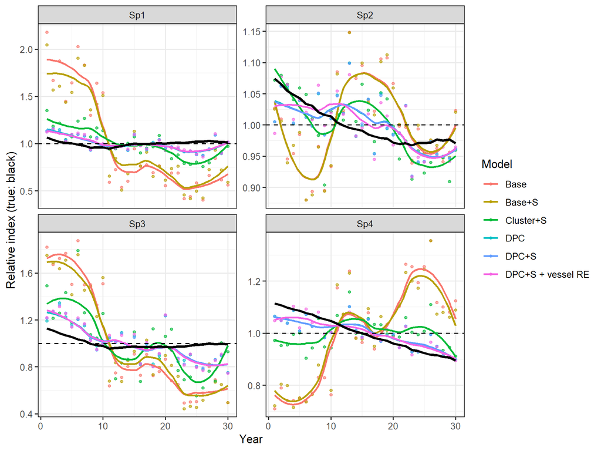

```r
plot_indices(fit, type = "points+smooth")
```

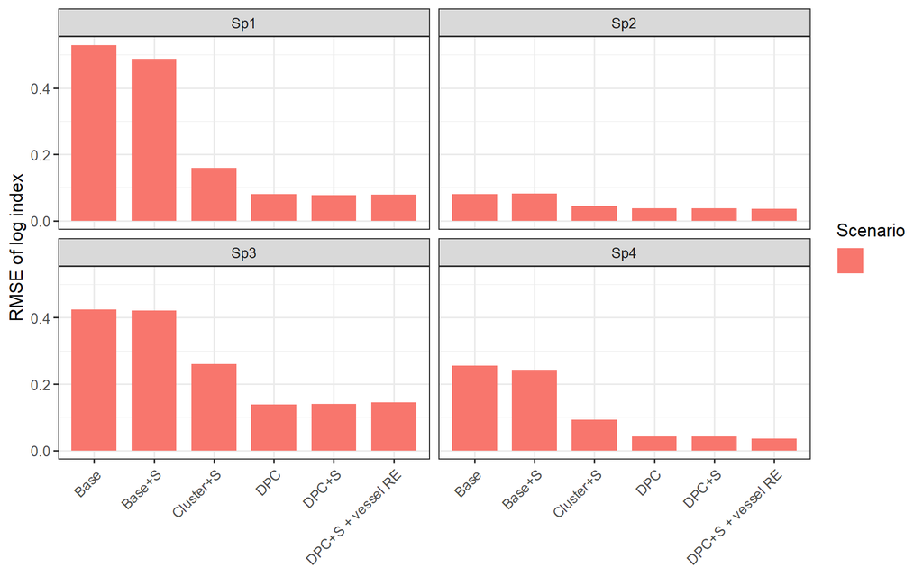

```r
plot_diagnostics(fit)
```

- The spatial term on 5 x 5 blocks hardly improves on Base: the habitat patches are smaller than the reporting blocks.
- DPC, with or without the spatial term, follows the true trends closely: the catch composition carries the fine-scale information that the reported positions lack.
- Three discrete clusters capture only part of a continuous gradient.

# What do the PCs capture?

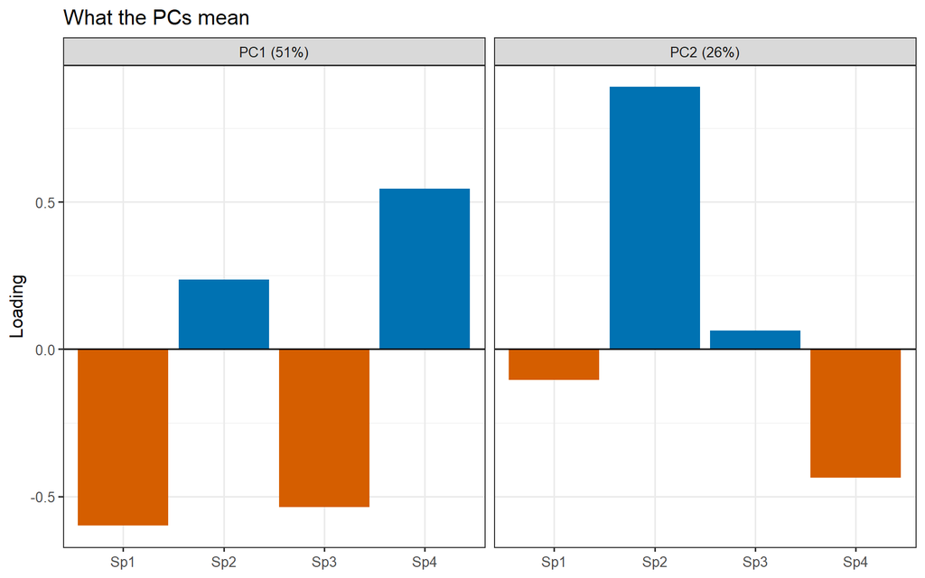

```r
pp <- plot_pcs(fit, pcs = c("PC1", "PC2"))
pp$loadings
```

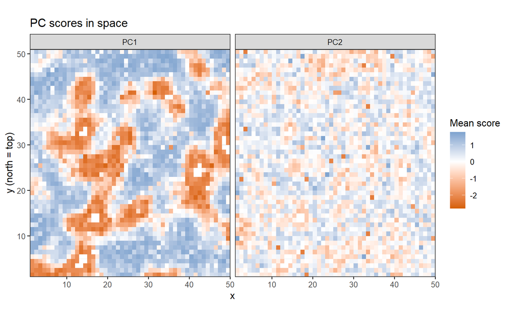

```r
pp$space
```

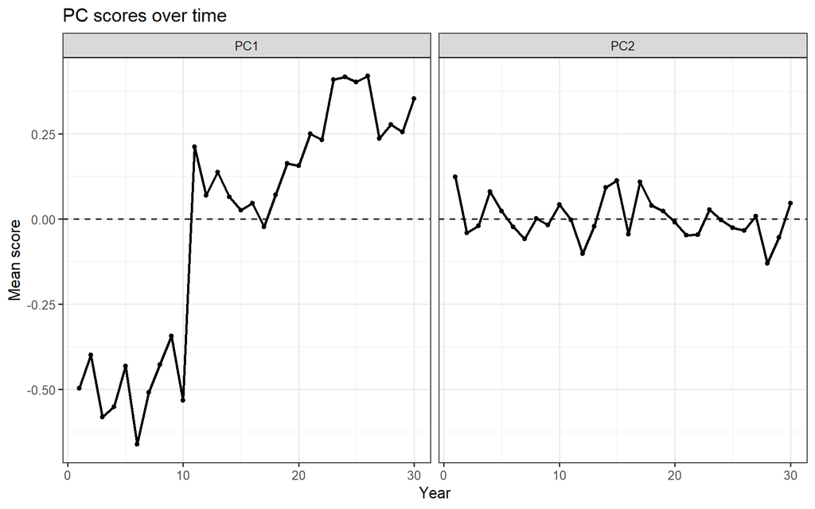

```r
pp$time
```

PC1 maps the habitat patches at the resolution of single cells, from catches alone, and jumps when the targeting changes (year 11). PC2 carries little signal, as in the guidelines, where only PC1 was non-trivial.

# What do the clusters capture?

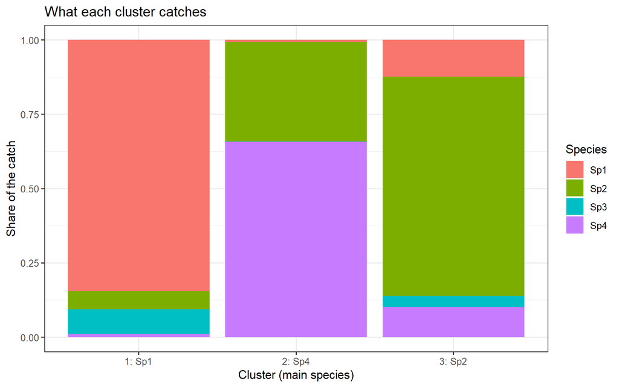

```r
pc <- plot_clusters(fit, switch_years = c(10.5, 20.5))
pc$composition
```

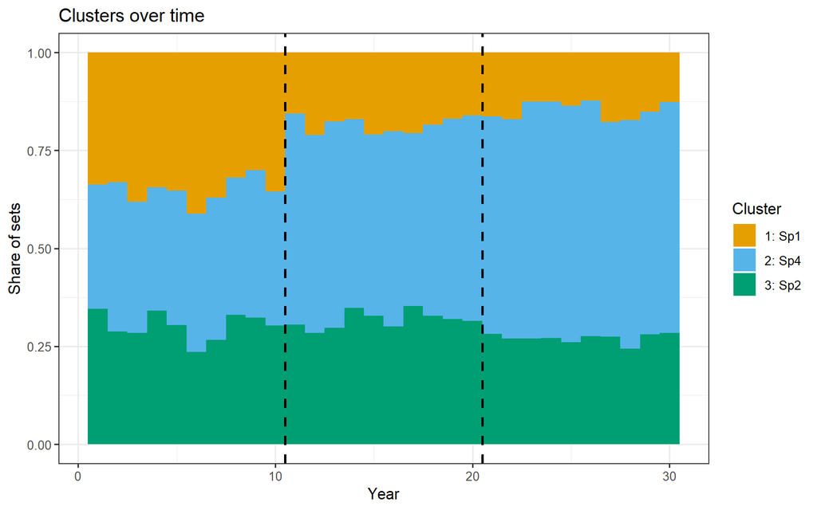

```r
pc$time
```

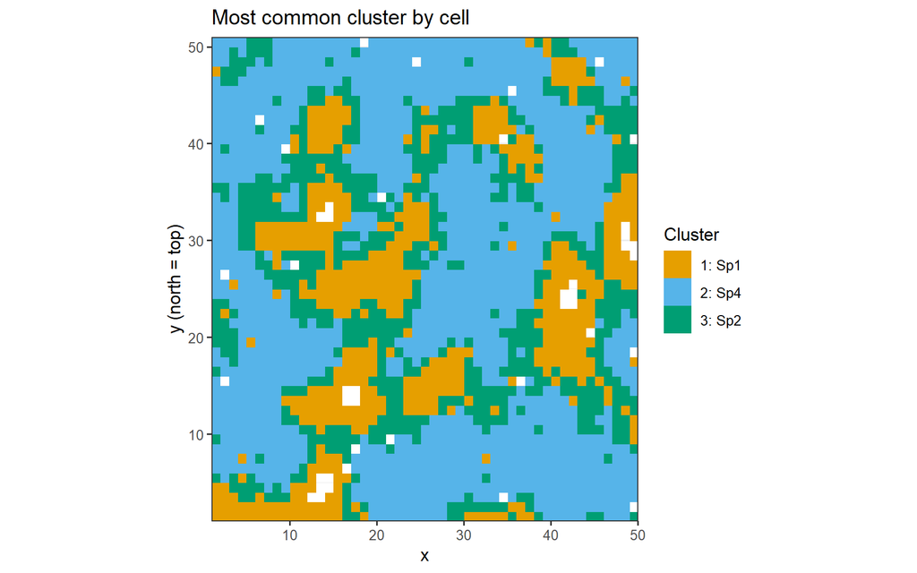

```r
pc$space
```

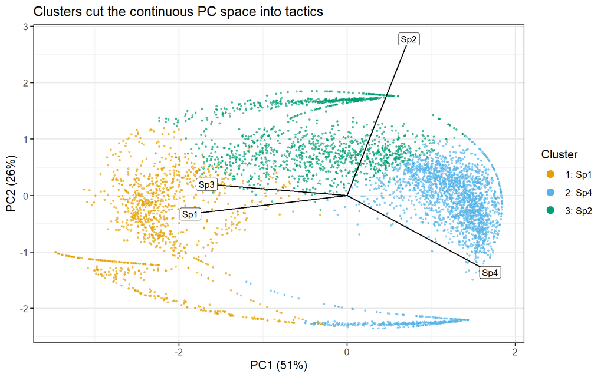

```r
pc$pca
```

The clusters cut the continuous cloud of catch compositions into three tactics. Their shares change with the targeting, but each cluster mixes sets from different parts of the gradient.

# Replicates

The same models (without the random vessel effect, and with `engine = "bam"`) over 20 seeds (`inst/scripts/run_bathymetric.R`):

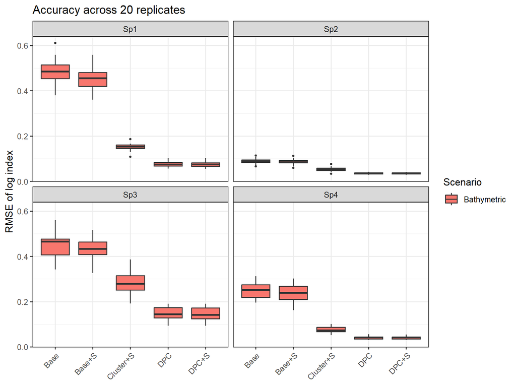

```r
reps <- readRDS(f_reps)
plot_replicates(reps)
```

# References

Ono, K., Punt, A.E. and Hilborn, R. (2015) Think outside the grids: an objective approach to define spatial strata for catch and effort analysis. Fisheries Research 170, 89-101.

Thorson, J.T., Fonner, R., Haltuch, M.A., Ono, K. and Winker, H. (2017) Accounting for spatiotemporal variation and fisher targeting when estimating abundance from multispecies fishery data. Canadian Journal of Fisheries and Aquatic Sciences 74, 1794-1807.

Winker, H., Kerwath, S.E. and Attwood, C.G. (2013) Comparison of two approaches to standardize catch-per-unit-effort for targeting behaviour in a multispecies hand-line fishery. Fisheries Research 139, 118-131.

Winker, H., Kerwath, S.E. and Attwood, C.G. (2014) Proof of concept for a novel procedure to standardize multispecies catch and effort data. Fisheries Research 155, 149-159.